# Renal pager data

09/12/2016

## Introduction

This is a summary document relating to pager activity for the renal baton.

The data do not account for calls to

– Personal pagers / mobiles

– Consultant on call

These data cover the period between 05 October, 2016 and 08 December, 2016 and describe 2352 pages sent out (note this number included multiple pages / reminders for individual encounters).

The system utilises a two-way pager system for calls originated via swtichboard. Doctors can acknowledge calls to aid communication with waiting referrers. Overall acknowledgement is as follows:

```
## Status_table
##         Accepted        Delivered Delivered & Read             Sent
##                2               44              812             1494
```

This, representative of all calls including those from within SRFT

Some pages did not have numeric data attached e.g. "Caller still waiting". As these cannot be linked to a specific episode they have been discarded

The division of calls origins is:

– Internal 1313 (56.4%)

– External 1017 (43.6%)

Of the external pages, where the two-way functionality has value, responses were given as follows:

```
## External_status_table
##         Accepted        Delivered Delivered & Read             Sent
##                1               16              350              650
```

## External calls

Of the 1017 pages made in relation to external calls, 116 (11.4%) were repeat calls due to the response taking > 15 mins

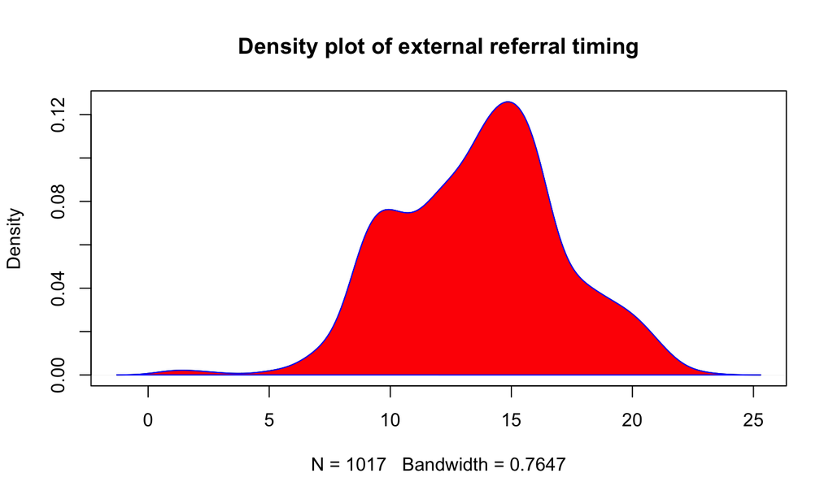

## Externals - office hours

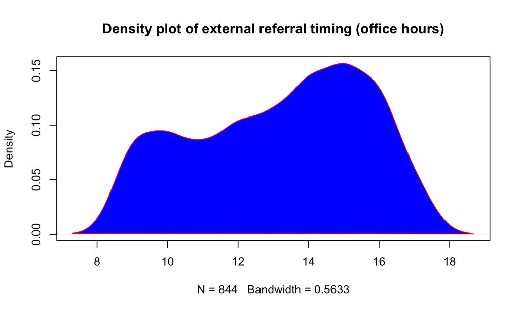

## Externals - on call hours

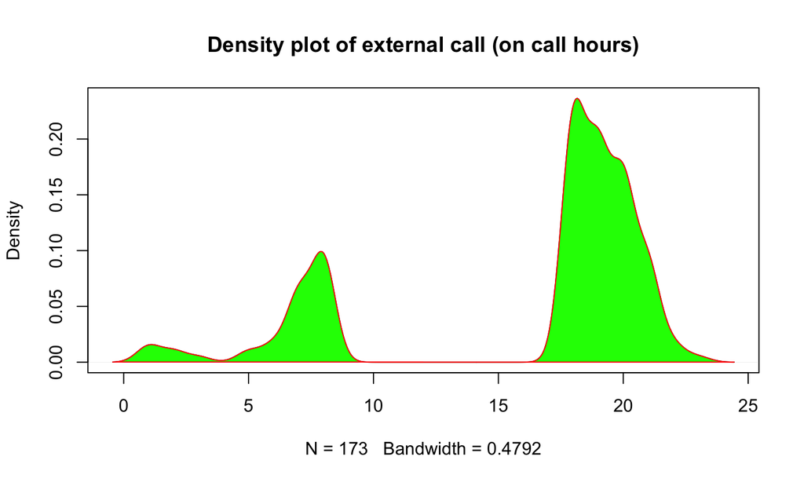

## Externals - repeated calls

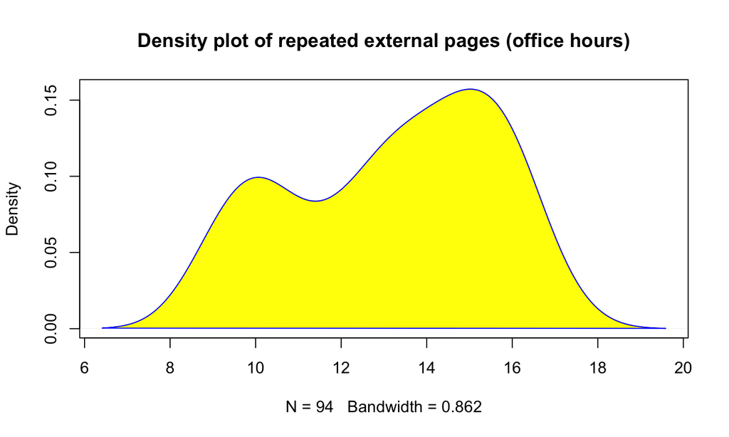

## Internal calls

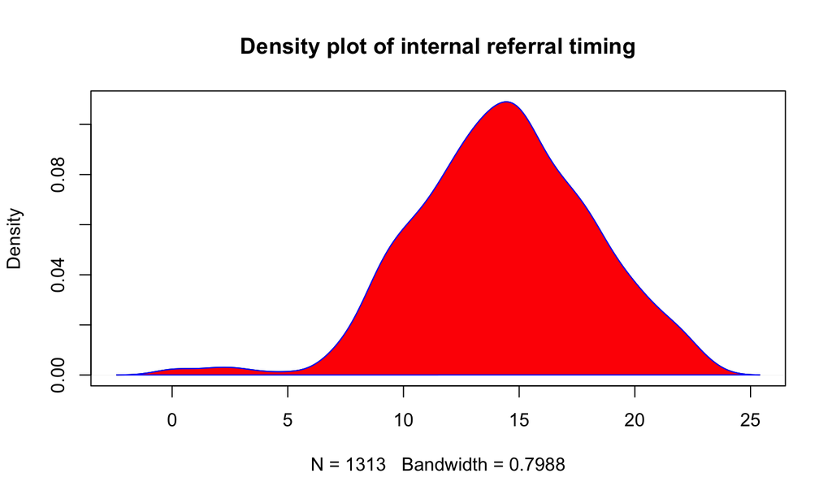

## Internals - office hours

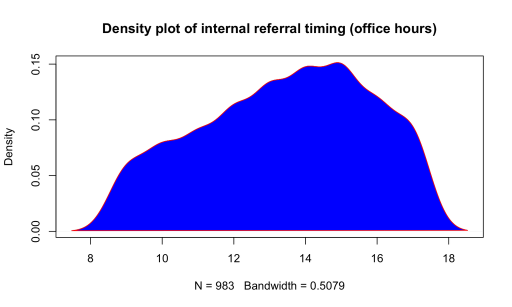

## Internals - on call hours

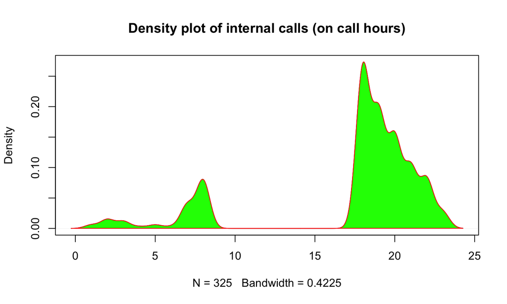

## Internals - repeated calls

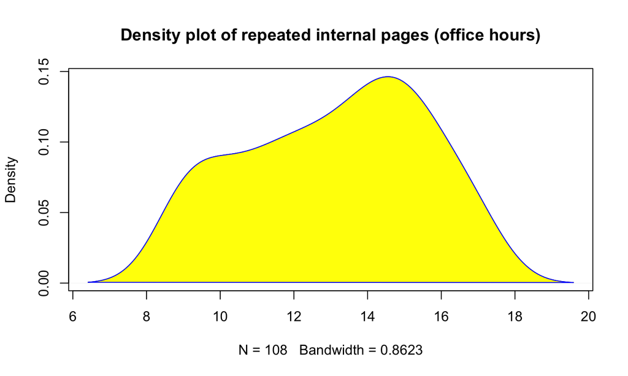

## Limitations

– Assumptions about nature of repeated calls

– Cannot account for other contemporaneous activiy

– Consultant / personal calls excluded

– Origin of calls not addressed

– Data do not capture time to response

## Conclusions

– Afternoon session has highest number of calls

– Both internal and external calls are greatest in the afternoon

– Need for additional support 1400-1600?

– Excluding repeat calls (15 mins window), there were 2095 referrals to the baton

– This is ~1050 calls per month

– Assuming 30 calendar days this is 35 pages / day (higher than 12 months ago - had been 30). Activity may be increasing

– No 'quiet time' for baton

– Poor use of 2-ways functionality to communicate with switchboard

## Further work

– Need to examine day to day variation (previous data show much lower number on Sunday)

– Address how many were made around repeated call events (consider if non-response was likely due to other calls)

– Consider system to allow time to response audit (likely JD driven)